# R Notebook ACM CAH type de lecteurs

Tout d’abord chargeons les packages utiles

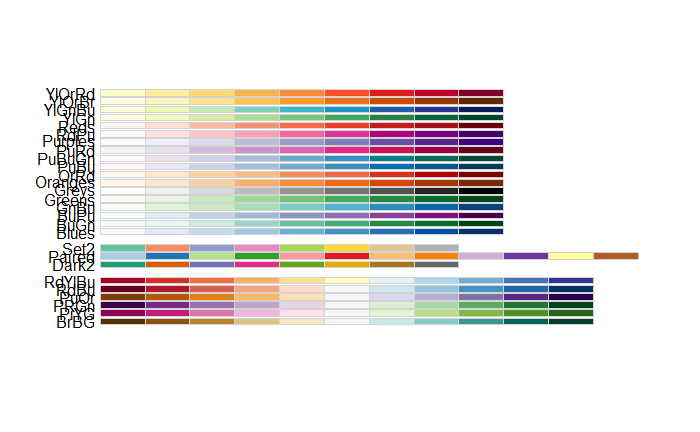

Construisons notre extrait de base de données avec les variables utiles pour l’ACM

```r
resacm2 <- bddpond %>%
  select(CLASS_univprat_name, CRITAGE, SEXE, DIPLOMrecodebis,62:74, 77,
         nb_livres_lus_4cl, freq_bibmed_rec, lire_autre_langue, manque_livre,
         Supports, div_genre_rec) %>%
  rename(
    AGE = CRITAGE,
    Univ_pratiques = CLASS_univprat_name,
    Diplome = DIPLOMrecodebis,
    nb_livres_lus = nb_livres_lus_4cl,
    freq_biblio = freq_bibmed_rec,
    nb_genres_lus = div_genre_rec
  ) %>%
  mutate(across(c(Diplome, lire_autre_langue), as.character)) %>%
  mutate(across(c(Diplome, lire_autre_langue), ~ na_if(.x, "REF"))) %>%
  mutate(across(c(Diplome, freq_biblio, lire_autre_langue), ~ na_if(.x, "NSP"))) %>%
  mutate(
    lire_autre_langue = replace_na(lire_autre_langue, "Non"),
    manque_livre = replace_na(manque_livre, "Non"),
  ) %>%
  mutate(across(5:18, ~ replace_na(.x, 0))) %>%
  mutate(across(5:18, ~ case_when(
    .x == 0 ~ "Non",
    .x == 1 ~ "Oui",
    TRUE ~ as.character(.x)
  ))) %>%
  filter(!is.na(Diplome) & !is.na(freq_biblio)) %>%
  mutate(across(everything(), as.factor))
```

Executons l’ACM. Les 4 premières variables et la dernière sont placées en variables supplémentaires illustratives

```r
res.MCA <- MCA(resacm2, quali.sup = c(1,2,3,4,24), graph = FALSE)
```

observons les valeurs propres

```r
summary(res.MCA)
```

```
Call:
MCA(X = resacm2, quali.sup = c(1, 2, 3, 4, 24), graph = FALSE)


Eigenvalues
                       Dim.1   Dim.2   Dim.3   Dim.4   Dim.5   Dim.6   Dim.7   Dim.8   Dim.9  Dim.10  Dim.11  Dim.12  Dim.13  Dim.14  Dim.15  Dim.16  Dim.17  Dim.18  Dim.19
Variance               0.281   0.100   0.092   0.065   0.055   0.053   0.052   0.049   0.046   0.044   0.042   0.041   0.038   0.036   0.036   0.034   0.033   0.032   0.030
% of var.             22.261   7.939   7.315   5.132   4.352   4.230   4.084   3.910   3.650   3.510   3.322   3.262   2.995   2.883   2.832   2.720   2.620   2.506   2.356
Cumulative % of var.  22.261  30.200  37.515  42.647  46.999  51.230  55.314  59.224  62.874  66.384  69.706  72.968  75.963  78.846  81.678  84.398  87.018  89.524  91.880
                      Dim.20  Dim.21  Dim.22  Dim.23  Dim.24
Variance               0.029   0.028   0.028   0.014   0.004
% of var.              2.263   2.250   2.189   1.098   0.320
Cumulative % of var.  94.143  96.393  98.583  99.680 100.000

Individuals (the 10 first)
                                 Dim.1    ctr   cos2    Dim.2    ctr   cos2    Dim.3    ctr   cos2
1                             |  0.093  0.000  0.009 |  0.126  0.002  0.016 | -0.144  0.002  0.021 |
2                             | -0.565  0.012  0.363 |  0.018  0.000  0.000 |  0.155  0.003  0.027 |
3                             |  0.250  0.002  0.050 | -0.064  0.000  0.003 | -0.005  0.000  0.000 |
4                             | -0.246  0.002  0.081 |  0.125  0.002  0.021 | -0.196  0.005  0.051 |
5                             | -0.638  0.016  0.867 | -0.071  0.001  0.011 |  0.225  0.006  0.108 |
6                             | -0.638  0.016  0.867 | -0.071  0.001  0.011 |  0.225  0.006  0.108 |
7                             | -0.638  0.016  0.867 | -0.071  0.001  0.011 |  0.225  0.006  0.108 |
8                             | -0.364  0.005  0.340 |  0.057  0.000  0.008 | -0.277  0.009  0.196 |
9                             | -0.638  0.016  0.867 | -0.071  0.001  0.011 |  0.225  0.006  0.108 |
10                            | -0.264  0.003  0.139 | -0.073  0.001  0.011 |  0.004  0.000  0.000 |

Categories (the 10 first)
                                  Dim.1     ctr    cos2  v.test     Dim.2     ctr    cos2  v.test     Dim.3     ctr    cos2  v.test
lire_litt_class_Non           |  -0.294   1.304   0.362 -57.469 |   0.077   0.249   0.025  14.994 |  -0.107   0.524   0.048 -20.875 |
lire_litt_class_Oui           |   1.233   5.474   0.362  57.469 |  -0.322   1.045   0.025 -14.994 |   0.448   2.198   0.048  20.875 |
lire_roman_policier_esp_Non   |  -0.363   1.678   0.280 -50.529 |  -0.034   0.041   0.002  -4.727 |   0.099   0.377   0.021  13.729 |
lire_roman_policier_esp_Oui   |   0.771   3.563   0.280  50.529 |   0.072   0.087   0.002   4.727 |  -0.209   0.800   0.021 -13.729 |
lire_roman_SF_horreur_etc_Non |  -0.173   0.476   0.170 -39.395 |  -0.192   1.638   0.209 -43.626 |  -0.067   0.215   0.025 -15.159 |
lire_roman_SF_horreur_etc_Oui |   0.984   2.709   0.170  39.395 |   1.089   9.316   0.209  43.626 |   0.379   1.221   0.025  15.159 |
lire_roman_hist_Non           |  -0.329   1.534   0.336 -55.325 |   0.120   0.573   0.045  20.187 |  -0.012   0.006   0.000  -2.005 |
lire_roman_hist_Oui           |   1.019   4.748   0.336  55.325 |  -0.372   1.773   0.045 -20.187 |   0.037   0.019   0.000   2.005 |
lire_roman_sentiment_Non      |  -0.038   0.024   0.014 -11.481 |  -0.012   0.007   0.001  -3.636 |   0.083   0.362   0.072  25.556 |
lire_roman_sentiment_Oui      |   0.385   0.247   0.014  11.481 |   0.122   0.069   0.001   3.636 |  -0.858   3.718   0.072 -25.556 |

```

[output cut: 18 more lines]

```
Eclect class                  |   1.106   0.155  37.597 |  -0.457   0.026 -15.526 |   0.317   0.013  10.779 |
Petit ecran                   |  -0.559   0.144 -36.224 |  -0.164   0.012 -10.593 |   0.086   0.003   5.575 |
Tout-num                      |  -0.403   0.020 -13.480 |   0.412   0.021  13.781 |   0.245   0.007   8.180 |
15-29 ans                     |  -0.005   0.000  -0.205 |   0.662   0.071  25.484 |   0.190   0.006   7.314 |
30-44 ans                     |  -0.008   0.000  -0.392 |   0.302   0.024  14.939 |  -0.001   0.000  -0.041 |
45-59 ans                     |   0.024   0.000   1.310 |  -0.055   0.001  -3.026 |  -0.001   0.000  -0.059 |
60-74 ans                     |   0.030   0.000   1.726 |  -0.308   0.035 -17.959 |  -0.076   0.002  -4.428 |

Supplementary categorical variables (eta2)
                                Dim.1 Dim.2 Dim.3
Univ_pratiques                | 0.324 0.120 0.072 |
AGE                           | 0.001 0.134 0.007 |
SEXE                          | 0.029 0.040 0.021 |
Diplome                       | 0.196 0.007 0.011 |
nb_genres_lus                 | 0.830 0.026 0.356 |
```

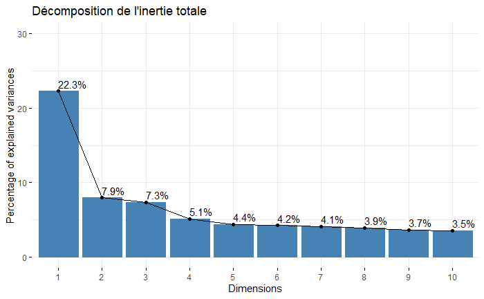

```r
fviz_screeplot(res.MCA, addlabels = TRUE, ylim = c(0, 30), title = "Décomposition de l'inertie totale")
```

Observons les coordonnées, les contributions et les cos2 des variables actives sur les premières dimensions de l’ACM

```r
res.MCA$var$coord
```

```
                                             Dim 1        Dim 2        Dim 3        Dim 4        Dim 5
lire_litt_class_Non                    -0.29377292  0.076646205 -0.106708577 -0.054881774 -0.010214433
lire_litt_class_Oui                     1.23284189 -0.321652021  0.447811207  0.230315821  0.042865697
lire_roman_policier_esp_Non            -0.36313289 -0.033968904  0.098667729  0.281798609  0.093849859
lire_roman_policier_esp_Oui             0.77103559  0.072125755 -0.209499973 -0.598339512 -0.199270249
lire_roman_SF_horreur_etc_Non          -0.17300342 -0.191584712 -0.066570168  0.082991564  0.010336992
lire_roman_SF_horreur_etc_Oui           0.98373499  1.089392247  0.378532424 -0.471908042 -0.058778382
lire_roman_hist_Non                    -0.32931069  0.120158181 -0.011931564 -0.013452162  0.018418483
lire_roman_hist_Oui                     1.01928089 -0.371913042  0.036930520  0.041637070 -0.057008803
lire_roman_sentiment_Non               -0.03750975 -0.011878129  0.083497492  0.138037123 -0.096348125
lire_roman_sentiment_Oui                0.38534429  0.122026114 -0.857784499 -1.418079760  0.989801321
lire_prix_litt_Non                     -0.25363467  0.159983828 -0.063002760  0.019133803  0.073688075
lire_prix_litt_Oui                      1.24451831 -0.784998366  0.309137894 -0.093884515 -0.361567914
lire_biographie_Non                    -0.19895522  0.111350134  0.021669950  0.017304580 -0.002279977
lire_biographie_Oui                     1.00667373 -0.563409484 -0.109645625 -0.087557724  0.011536229
lire_autre_roman_cont_Non              -0.29226379  0.148090003 -0.028549500  0.100194467  0.064041883
lire_autre_roman_cont_Oui               1.04112579 -0.527538226  0.101701346 -0.356920861 -0.228135192
lire_BD_Non                            -0.23442744 -0.244518254 -0.080114188 -0.015706685  0.130131863
lire_BD_Oui                             0.89977853  0.938509054  0.307493977  0.060285342 -0.499471635
lire_Comics_Non                        -0.06484208 -0.142449392 -0.070579248  0.009469171  0.041160825
lire_Comics_Oui                         1.14944898  2.525186039  1.251151233 -0.167859035 -0.729653806
lire_Mangas_Non                        -0.06632803 -0.160346259 -0.072013780  0.012782318  0.015755020
lire_Mangas_Oui                         1.04156870  2.517964876  1.130853747 -0.200724533 -0.247405747
lire_essais_Non                        -0.27128804  0.008240912 -0.038559074 -0.265133122 -0.070738557
lire_essais_Oui                         0.95901873 -0.029132097  0.136308531  0.937260748  0.250064844
lire_livre_actu_Non                    -0.18889270  0.070315635  0.019496445 -0.200893928  0.009856399
lire_livre_actu_Oui                     0.94520961 -0.351855918 -0.097559233  1.005263165 -0.049320929
lire_beau_livre_Non                    -0.22125603  0.041849710 -0.066120298 -0.125866758  0.049277703
lire_beau_livre_Oui                     1.18003215 -0.223198452  0.352641587  0.671289375 -0.262814417
0 livre                                -1.09336139 -0.172725548  0.713526680  0.052559871 -0.065465498
1 à 9 livres                            0.11304924  0.426440173 -0.959931770  0.181387083  0.323439522
10 à 19 livres                          0.63573767 -0.092365199 -0.293506782  0.159805522 -1.210071950
20 livres et plus                       1.12507688 -0.354054683  0.660685739 -0.523917488  0.549383018
bibl_Au moins 1 fois par mois           0.90717860 -0.215541407  0.271992749 -0.378809040  0.463605416
bibl_Moins d'une fois par mois          0.45023790  0.509237275 -0.407242093  0.586808109 -0.163924974
bibl_Jamais                            -0.28317765 -0.025665919 -0.003114122  0.001375412 -0.085283287
lire_autre_langue_Non                  -0.14965530 -0.051401378 -0.058593941 -0.083718948 -0.171493017
lire_autre_langue_Oui                   1.03820919  0.356588671  0.406485901  0.580786541  1.189704823
manque_livre_Oui, beaucoup              0.97547542 -0.407170855  0.264400891 -0.284732719 -0.019527679
manque_livre_Oui, un peu                0.28599523  0.616166701 -1.221737630  0.356667612  0.103302032
manque_livre_Non                       -0.81703844  0.045143608  0.301208098  0.061423918 -0.027503514
Aucun_support                          -1.09547949 -0.174374558  0.728266129  0.040891851 -0.060387500
Papier_non_exclusif_ou_autres_supports  0.94111278  0.721646985  0.841283860  0.145599790  1.441995674
Papier_uniquement                       0.45538454 -0.003030232 -0.496456084 -0.040865333 -0.158473802
```

```r
res.MCA$var$contrib
```

```
                                            Dim 1        Dim 2        Dim 3        Dim 4        Dim 5
lire_litt_class_Non                    1.30449296 2.490002e-01 5.237515e-01 1.974855e-01 8.066605e-03
lire_litt_class_Oui                    5.47441062 1.044950e+00 2.197966e+00 8.287637e-01 3.385216e-02
lire_roman_policier_esp_Non            1.67790878 4.117185e-02 3.769605e-01 4.383040e+00 5.732558e-01
lire_roman_policier_esp_Oui            3.56268302 8.741969e-02 8.003955e-01 9.306455e+00 1.217187e+00
lire_roman_SF_horreur_etc_Non          0.47642293 1.638344e+00 2.146599e-01 4.755671e-01 8.699929e-03
lire_roman_SF_horreur_etc_Oui          2.70904418 9.315981e+00 1.220603e+00 2.704178e+00 4.946968e-02
lire_roman_hist_Non                    1.53414146 5.727441e-01 6.128538e-03 1.110449e-02 2.454740e-02
lire_roman_hist_Oui                    4.74846748 1.772755e+00 1.896902e-02 3.437056e-02 7.597900e-02
lire_roman_sentiment_Non               0.02399867 6.748309e-03 3.618712e-01 1.409779e+00 8.098961e-01
lire_roman_sentiment_Oui               0.24654254 6.932657e-02 3.717567e+00 1.448291e+01 8.320206e+00
lire_prix_litt_Non                     1.00023649 1.115932e+00 1.878075e-01 2.469157e-02 4.318410e-01
lire_prix_litt_Oui                     4.90789613 5.475584e+00 9.215219e-01 1.211550e-01 2.118930e+00
lire_biographie_Non                    0.61862298 5.433717e-01 2.233261e-02 2.030010e-02 4.155472e-04
lire_biographie_Oui                    3.13010896 2.749353e+00 1.129986e-01 1.027144e-01 2.102586e-03
lire_autre_roman_cont_Non              1.24835036 8.987484e-01 3.624865e-02 6.364064e-01 3.065905e-01
lire_autre_roman_cont_Oui              4.44697495 3.201594e+00 1.291279e-01 2.267059e+00 1.092162e+00
lire_BD_Non                            0.81602021 2.489469e+00 2.900089e-01 1.588963e-02 1.286161e+00
lire_BD_Oui                            3.13204572 9.555072e+00 1.113111e+00 6.098751e-02 4.936538e+00
lire_Comics_Non                        0.07449396 1.008158e+00 2.685775e-01 6.891150e-03 1.535392e-01
lire_Comics_Oui                        1.32054694 1.787152e+01 4.761047e+00 1.221587e-01 2.721775e+00
lire_Mangas_Non                        0.07741465 1.268665e+00 2.776953e-01 1.247122e-02 2.234143e-02
lire_Mangas_Oui                        1.21566516 1.992222e+01 4.360732e+00 1.958392e-01 3.508340e-01
lire_essais_Non                        1.07377995 2.778464e-03 6.601089e-02 4.448797e+00 3.734310e-01
lire_essais_Oui                        3.79587354 9.822029e-03 2.333523e-01 1.572675e+01 1.320100e+00
lire_livre_actu_Non                    0.55660429 2.162819e-01 1.804411e-02 2.730929e+00 7.751698e-03
lire_livre_actu_Oui                    2.78522004 1.082264e+00 9.029182e-02 1.366543e+01 3.878911e-02
lire_beau_livre_Non                    0.77160837 7.740906e-02 2.096934e-01 1.083152e+00 1.957725e-01
lire_beau_livre_Oui                    4.11524464 4.128483e-01 1.118365e+00 5.776810e+00 1.044120e+00
0 livre                                7.24742015 5.071884e-01 9.392578e+00 7.264825e-02 1.329000e-01
1 à 9 livres                           0.07789996 3.108267e+00 1.709193e+01 8.699118e-01 3.261611e+00
10 à 19 livres                         1.18946189 7.040630e-02 7.715060e-01 3.260159e-01 2.204251e+01
20 livres et plus                      4.57736756 1.271137e+00 4.803410e+00 4.305641e+00 5.582720e+00
bibl_Au moins 1 fois par mois          2.63315963 4.168245e-01 7.203020e-01 1.991558e+00 3.517488e+00
bibl_Moins d'une fois par mois         0.41229041 1.478971e+00 1.026438e+00 3.037889e+00 2.795461e-01
bibl_Jamais                            1.08125670 2.490719e-02 3.979152e-04 1.106463e-04 5.016291e-01
lire_autre_langue_Non                  0.36638903 1.212015e-01 1.709118e-01 4.973549e-01 2.460907e+00
lire_autre_langue_Oui                  2.54176414 8.408156e-01 1.185673e+00 3.450319e+00 1.707214e+01
manque_livre_Oui, beaucoup             6.04029376 2.951066e+00 1.350391e+00 2.232342e+00 1.238143e-02
manque_livre_Oui, un peu               0.29024052 3.777784e+00 1.611776e+01 1.958071e+00 1.936878e-01
manque_livre_Non                       5.88839414 5.040860e-02 2.435306e+00 1.443602e-01 3.412969e-02
Aucun_support                          7.15484318 5.083444e-01 9.622329e+00 4.324399e-02 1.112064e-01
Papier_non_exclusif_ou_autres_supports 1.31785259 2.172868e+00 3.204623e+00 1.368250e-01 1.582543e+01
Papier_uniquement                      2.33654634 2.901147e-04 8.450607e+00 8.161848e-02 1.447361e+00
```

```r
res.MCA$var$cos2
```

```
                                             Dim 1        Dim 2        Dim 3        Dim 4        Dim 5
lire_litt_class_Non                    0.362175556 2.465341e-02 4.778530e-02 1.264014e-02 4.378488e-04
lire_litt_class_Oui                    0.362175556 2.465341e-02 4.778530e-02 1.264014e-02 4.378488e-04
lire_roman_policier_esp_Non            0.279988382 2.450033e-03 2.067089e-02 1.686112e-01 1.870148e-02
lire_roman_policier_esp_Oui            0.279988382 2.450033e-03 2.067089e-02 1.686112e-01 1.870148e-02
lire_roman_SF_horreur_etc_Non          0.170189517 2.087109e-01 2.519897e-02 3.916439e-02 6.075917e-04
lire_roman_SF_horreur_etc_Oui          0.170189517 2.087109e-01 2.519897e-02 3.916439e-02 6.075917e-04
lire_roman_hist_Non                    0.335660090 4.468839e-02 4.406389e-04 5.601086e-04 1.050016e-03
lire_roman_hist_Oui                    0.335660090 4.468839e-02 4.406389e-04 5.601086e-04 1.050016e-03
lire_roman_sentiment_Non               0.014454168 1.449442e-03 7.162285e-02 1.957476e-01 9.536550e-02
lire_roman_sentiment_Oui               0.014454168 1.449442e-03 7.162285e-02 1.957476e-01 9.536550e-02
lire_prix_litt_Non                     0.315652995 1.255870e-01 1.947654e-02 1.796368e-03 2.664324e-02
lire_prix_litt_Oui                     0.315652995 1.255870e-01 1.947654e-02 1.796368e-03 2.664324e-02
lire_biographie_Non                    0.200282990 6.273572e-02 2.376015e-03 1.515150e-03 2.630234e-05
lire_biographie_Oui                    0.200282990 6.273572e-02 2.376015e-03 1.515150e-03 2.630234e-05
lire_autre_roman_cont_Non              0.304283368 7.812314e-02 2.903523e-03 3.576150e-02 1.461021e-02
lire_autre_roman_cont_Oui              0.304283368 7.812314e-02 2.903523e-03 3.576150e-02 1.461021e-02
lire_BD_Non                            0.210932779 2.294826e-01 2.463463e-02 9.468829e-04 6.499717e-02
lire_BD_Oui                            0.210932779 2.294826e-01 2.463463e-02 9.468829e-04 6.499717e-02
lire_Comics_Non                        0.074532660 3.597112e-01 8.830531e-02 1.589486e-03 3.003315e-02
lire_Comics_Oui                        0.074532660 3.597112e-01 8.830531e-02 1.589486e-03 3.003315e-02
lire_Mangas_Non                        0.069085198 4.037462e-01 8.143705e-02 2.565725e-03 3.897882e-03
lire_Mangas_Oui                        0.069085198 4.037462e-01 8.143705e-02 2.565725e-03 3.897882e-03
lire_essais_Non                        0.260170312 2.400751e-04 5.255931e-03 2.484989e-01 1.768923e-02
lire_essais_Oui                        0.260170312 2.400751e-04 5.255931e-03 2.484989e-01 1.768923e-02
lire_livre_actu_Non                    0.178543193 2.474097e-02 1.902058e-03 2.019513e-01 4.861268e-04
lire_livre_actu_Oui                    0.178543193 2.474097e-02 1.902058e-03 2.019513e-01 4.861268e-04
lire_beau_livre_Non                    0.261089229 9.340790e-03 2.331677e-02 8.449302e-02 1.295089e-02
lire_beau_livre_Oui                    0.261089229 9.340790e-03 2.331677e-02 8.449302e-02 1.295089e-02
0 livre                                0.572709565 1.429289e-02 2.439088e-01 1.323474e-03 2.053203e-03
1 à 9 livres                           0.006171868 8.782083e-02 4.450021e-01 1.588891e-02 5.052048e-02
10 à 19 livres                         0.075405786 1.591716e-03 1.607256e-02 4.764665e-03 2.731940e-01
20 livres et plus                      0.303117158 3.001835e-02 1.045288e-01 6.573125e-02 7.227641e-02
bibl_Au moins 1 fois par mois          0.169688522 9.579179e-03 1.525392e-02 2.958745e-02 4.431634e-02
bibl_Moins d'une fois par mois         0.024712724 3.161381e-02 2.021817e-02 4.197868e-02 3.275871e-03
bibl_Jamais                            0.206606104 1.697223e-03 2.498598e-05 4.874059e-06 1.873929e-02
lire_autre_langue_Non                  0.155373503 1.832915e-02 2.381761e-02 4.862284e-02 2.040261e-01
lire_autre_langue_Oui                  0.155373503 1.832915e-02 2.381761e-02 4.862284e-02 2.040261e-01
manque_livre_Oui, beaucoup             0.488327730 8.508090e-02 3.587604e-02 4.160576e-02 1.956951e-04
manque_livre_Oui, un peu               0.019134158 8.881539e-02 3.491787e-01 2.975906e-02 2.496373e-03
manque_livre_Non                       0.595009888 1.816485e-03 8.086722e-02 3.362902e-03 6.742417e-04
Aucun_support                          0.560936246 1.421253e-02 2.479050e-01 7.815892e-04 1.704508e-03
Papier_non_exclusif_ou_autres_supports 0.076489294 4.497456e-02 6.112268e-02 1.830791e-03 1.795747e-01
Papier_uniquement                      0.313633389 1.388729e-05 3.727584e-01 2.525665e-03 3.798225e-02
```

Enfin, décrivons les axes. Pour chacun des 3 premiers axes, on peut observer le lien entre l’axe et les variables et entre l’axe et les modalités.

```r
dimdesc(res.MCA)
```

```
$`Dim 1`

Link between the variable and the categorical variable (1-way anova)
=============================================
                                   R2       p.value
Univ_pratiques            0.323646277  0.000000e+00
Diplome                   0.196134569  0.000000e+00
lire_litt_class           0.362175556  0.000000e+00
lire_roman_policier_esp   0.279988382  0.000000e+00
lire_roman_SF_horreur_etc 0.170189517  0.000000e+00
lire_roman_hist           0.335660090  0.000000e+00
lire_prix_litt            0.315652995  0.000000e+00
lire_biographie           0.200282990  0.000000e+00
lire_autre_roman_cont     0.304283368  0.000000e+00
lire_BD                   0.210932779  0.000000e+00
lire_essais               0.260170312  0.000000e+00
lire_livre_actu           0.178543193  0.000000e+00
lire_beau_livre           0.261089229  0.000000e+00
nb_livres_lus             0.699472488  0.000000e+00
freq_biblio               0.220476998  0.000000e+00
lire_autre_langue         0.155373503  0.000000e+00
manque_livre              0.652819021  0.000000e+00
Supports                  0.577503902  0.000000e+00
nb_genres_lus             0.830105217  0.000000e+00
lire_Comics               0.074532660 1.334927e-155
lire_Mangas               0.069085198 5.781546e-144
SEXE                      0.029170849  1.180313e-60
lire_roman_sentiment      0.014454168  1.026695e-30
AGE                       0.001403799  1.226354e-02

Link between variable and the categories of the categorical variables
================================================================
                                                           Estimate       p.value
nb_genres_lus=5 genres ou plus                           0.64975281  0.000000e+00
Supports=Papier_uniquement                               0.18827245  0.000000e+00
manque_livre=manque_livre_Oui, beaucoup                  0.43871504  0.000000e+00
lire_autre_langue=lire_autre_langue_Oui                  0.31494879  0.000000e+00
freq_biblio=bibl_Au moins 1 fois par mois                0.29117473  0.000000e+00
nb_livres_lus=20 livres et plus                          0.49313206  0.000000e+00
lire_beau_livre=lire_beau_livre_Oui                      0.37153566  0.000000e+00
```

[output cut: 229 more lines]

```
SEXE=Femme                                              -0.044568722  1.382243e-44
lire_beau_livre=lire_beau_livre_Non                     -0.063648181  1.055449e-48
lire_autre_langue=lire_autre_langue_Non                 -0.070688110  1.007592e-49
lire_BD=lire_BD_Non                                     -0.058913086  2.178745e-51
lire_roman_SF_horreur_etc=lire_roman_SF_horreur_etc_Non -0.067651741  1.539642e-52
lire_litt_class=lire_litt_class_Non                     -0.084282207  4.302495e-99
Univ_pratiques=Bain audio                               -0.153922998 6.200938e-110
lire_roman_sentiment=lire_roman_sentiment_Oui           -0.143066714 2.236463e-149
nb_genres_lus=3 ou 4 genres                             -0.144568294 6.240397e-165
lire_Mangas=lire_Mangas_Non                             -0.182825451 1.903761e-170
lire_Comics=lire_Comics_Non                             -0.200891591 2.523580e-185
nb_genres_lus=1 ou 2 genres                             -0.203617555  0.000000e+00
Supports=Papier_uniquement                              -0.259648043  0.000000e+00
manque_livre=manque_livre_Oui, un peu                   -0.304903171  0.000000e+00
nb_livres_lus=1 à 9 livres                              -0.300980929  0.000000e+00
```

Représentations graphiques

Représentons tout d’abord le nuage des individus en fonction de la qualité de leur représentation (cos2) sur la première dimension

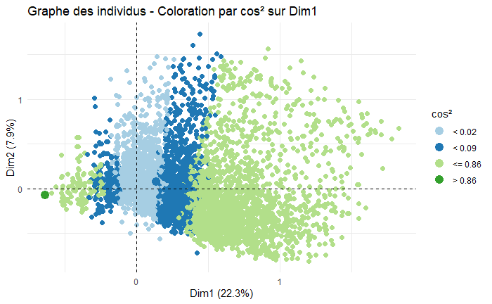

```r
# Sélectionner une palette de couleur adaptée aux daltoniens
palette_cblind <- brewer.pal(4, "Paired")  # 4 classes = 4 couleurs

# Récupérer le cos² des individus
cos2_ind <- res.MCA$ind$cos2[, 1]  # Cos2 sur la première dimension

# Définir  les catégories de cos2 pour la légende
breaks_cos2 <- c(0, 0.02, 0.09, 0.86, 1)
labels_cos2 <- c("< 0.02", "< 0.09", "<= 0.86", "> 0.86")  # étiquette dans la légende

# Catégoriser les individus selon ces seuils
cos2_classes <- cut(cos2_ind, breaks = breaks_cos2, include.lowest = TRUE, labels = labels_cos2)

# Graphique avec la légende correcte
fviz_mca_ind(res.MCA,
             label = "none",
             habillage = cos2_classes,  # Coloration des points selon les classes de cos²
             addEllipses = FALSE,
             pointsize = 2) +
  scale_color_manual(values = palette_cblind, name = "cos²") +  # Applique les couleurs aux classes
  labs(title = "Graphe des individus - Coloration par cos² sur Dim1") +
  theme_minimal()
```

On peut représenter le nuage des individus en fonction des modalités des 5 variables illustratives

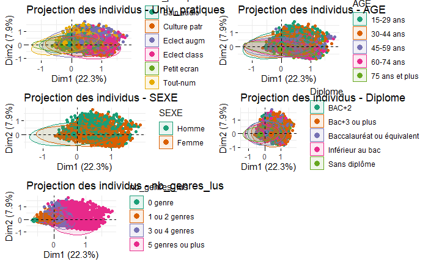

```r
# on crée une liste des variables supplémentaires
quali_sup_indices <- c(1, 2, 3, 4, 24)

#on applique successivement à chaque variable supplémentaire le code du graphique grâce à une fonction
plots <- lapply(quali_sup_indices, function(i) {
  fviz_mca_ind(res.MCA, label = "none", habillage = i,axes=c(1,2), addEllipses = TRUE,
               palette = "Dark2", title = paste("Projection des individus -", colnames(resacm2)[i])) #on utilise le nom des variables pour identifier chacun des futures graphiques
})

# On affiche les 5 graphiques en même temps (grâce à gridExtra)
library(gridExtra)
do.call(grid.arrange, c(plots, ncol = 2))  # affichage en 2 colonnes
```

La librairie explor est utiliser pour visualiser les différents graphs, dont celui des modalités

```r
explor(res.MCA)
```

```
Listening on http://127.0.0.1:7007
```

On peut placer les labels dans explor et en récuperer les coordonnées sur le plan afin de l’insérer dans notre code. On peut alors générer le graph des modalités.

```r
res <- explor::prepare_results(res.MCA)
label_df_supp<-read.csv("C:/ad.univ-lille.fr/Personnels/Homedir1/4273/Documents/Cours 2024-2025/Master 1 ENSP travail R/AGD/AGD/position_labels_ACM_supp.csv", sep=",", header=TRUE)

label_df_supp <- label_df_supp[label_df_supp$lab %in% rownames(res$var$coord), ]

# Fusionner les coordonnées avec res$var
res$var$coord[rownames(res$var$coord) %in% label_df_supp$lab, "Dim 1"] <- label_df_supp$lab_x
res$var$coord[rownames(res$var$coord) %in% label_df_supp$lab, "Dim 2"] <- label_df_supp$lab_y


explor::MCA_var_plot(res, xax = 1, yax = 2, var_sup = TRUE, var_sup_choice = c("Univ_pratiques",
                                                                               "AGE", "SEXE", "Diplome", "nb_genres_lus"), var_lab_min_contrib = 0, col_var = "Type",
                     symbol_var = "Variable", size_var = "Contrib", size_range = c(52.5, 700), #on utilise la contribution pour définir la taille des points pour les modalités actives
                     labels_size = 10, point_size = 56, transitions = TRUE, labels_positions = "auto",
                     labels_prepend_var = FALSE, xlim = c(-2.28, 2.35), ylim = c(-1.45, 3.19))
```

[interactive chart not shown]

On peut également représenter le graph des variables

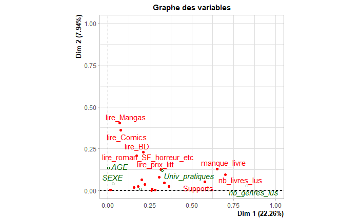

```r
plot.MCA(res.MCA, choix='var',title="Graphe des variables")
```

Procédons maintenant à la CAH. La construction se fait sur les 13 premières dimensions (plus de 75% de l’inertie).

```r
res.MCA<-MCA(resacm2,ncp=13,quali.sup=c(1,2,3,4,24),graph=FALSE)
```

Observons les gains d’inertie pour pouvoir choisir le nombre de classes que nous voulons contruire

```r
inertie_gains <- res.HCPC$call$t$inert.gain

# Sélection des 10 premiers gains d'inertie
(inertie_gains_10 <- inertie_gains[1:10])
```

```
 [1] 0.18923460 0.06862553 0.05532194 0.04079875 0.03674619 0.03151928 0.02993463 0.01714485 0.01285602 0.01152598
```

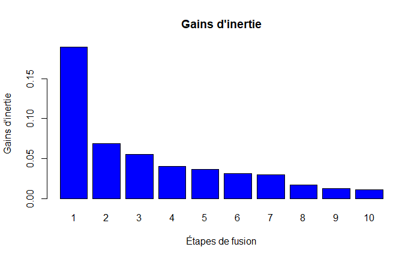

```r
# Création du diagramme en barres
barplot(
  inertie_gains_10,
  names.arg = 1:10,
  col = "blue",
  main = "Gains d'inertie",
  xlab = "Étapes de fusion",
  ylab = "Gains d'inertie",
  border = "black"
)
```

L’observation des valeurs nous indique que le passage d’un groupement en 4 classes à 5 classes entrâine un saut d’inertie. On gardera donc 4 classes.

On peut maintenant faire la CAH en 4 classes que l’on consolidera avec la méthode des K-means

```r
res.HCPC<-HCPC(res.MCA,nb.clust=4,consol=TRUE,graph=FALSE)
```

Les résultats sont visibles dans le dendrogramme

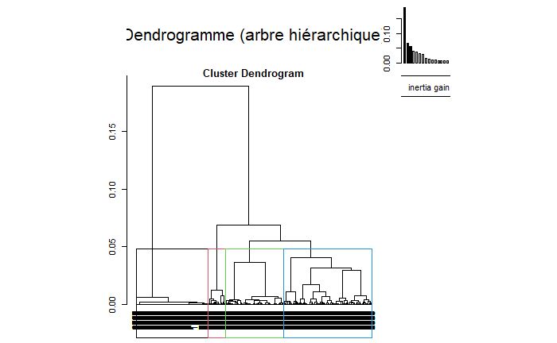

```r
plot.HCPC(res.HCPC,choice='tree',title='Dendrogramme (arbre hiérarchique)')
```

4 clusters sont créés et on peut représenter le nuage des individus en fonction de leur appartenance aux clusters

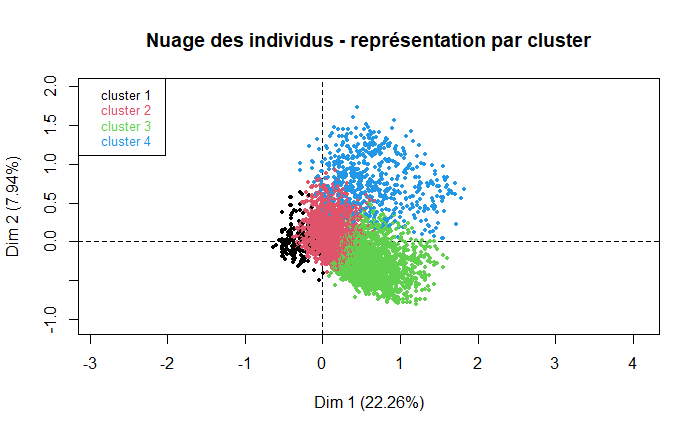

```r
plot.HCPC(res.HCPC,choice='map',draw.tree=FALSE,label="none",title="Nuage des individus - représentation par cluster")
```

On peut, si on le souhaite, ajouter les modalités des variables illustratives sur ce graph (mais cela donne un rendu trop chargé pour être vraiment lisible)

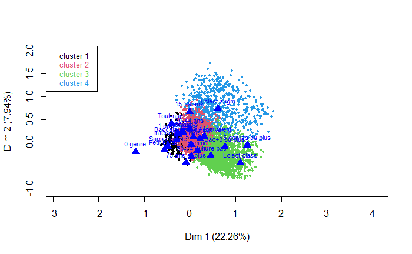

Enfin, on peut représenter le dendrogramme sur le nuage des individus

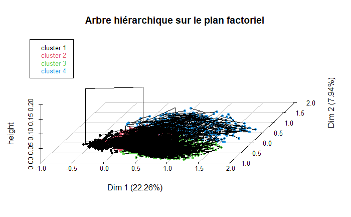

```r
plot.HCPC(res.HCPC,choice='3D.map',ind.names=FALSE,centers.plot=FALSE,angle=60,title='Arbre hiérarchique sur le plan factoriel')
```

Il nous reste à décrire les différentes classes.

Pour cela on peut faire apparaitre les parangons (les individus les plus proches des barycentres des classes) et les individus spécifiques (les plus éloignés des barycentres des autres classes)

```r
res.HCPC[["desc.ind"]][["para"]]
```

```
Cluster: 1
        34          9         22         47         48
0.04344517 0.04344517 0.04344517 0.04344517 0.04344517
----------------------------------------------------------------------------------------------------------------------------------
Cluster: 2
      652      1486      2145      2967      4165
0.2944157 0.2944157 0.2944157 0.2944157 0.2944157
----------------------------------------------------------------------------------------------------------------------------------
Cluster: 3
     4668      2729       896      4332      8678
0.4241827 0.4318050 0.4469769 0.4548531 0.4548531
----------------------------------------------------------------------------------------------------------------------------------
Cluster: 4
     8035       325      5567      8086        51
0.6299730 0.6719237 0.6780114 0.6781877 0.6896706
```

```r
res.HCPC[["desc.ind"]][["dist"]]
```

```
Cluster: 1
    5636     1152     5826       42     5859
1.341552 1.325401 1.324149 1.317152 1.202797
----------------------------------------------------------------------------------------------------------------------------------
Cluster: 2
    1136     7487     8672     7140     7573
1.665811 1.622782 1.618744 1.616285 1.607479
----------------------------------------------------------------------------------------------------------------------------------
Cluster: 3
    8644     4356     6992     7631     3297
1.960154 1.944628 1.919663 1.898142 1.880940
----------------------------------------------------------------------------------------------------------------------------------
Cluster: 4
     313     1713     1689     6861     4956
2.155936 2.154586 2.121420 2.116966 2.101900
```

L’ensemble des valeurs qu’il faut analyser pour caractériser les classes sont accessibles

```r
summary(res.HCPC)
```

```
           Length Class      Mode
data.clust 25     data.frame list
desc.var    3     catdes     list
desc.axes   3     catdes     list
desc.ind    2     -none-     list
call        8     -none-     list
```

Dans res.HPCP on peut avoir accès à toutes les données utiles pour l’analyse et notamment:

-les liens entre les dimensions de l’ACM et la classification (les Eta2 nous donnent les rapports de correlation. On s’aperçoit que seuls les 3 premiers axes sont raiment reliés à la CAH)

```r
res.HCPC[["desc.axes"]][["quanti.var"]]
```

```
              Eta2      P-value
Dim.1  0.831610181 0.000000e+00
Dim.2  0.639039229 0.000000e+00
Dim.3  0.654478480 0.000000e+00
Dim.10 0.034322338 1.037773e-68
Dim.6  0.026995402 8.451031e-54
Dim.5  0.022243276 3.385268e-44
Dim.8  0.015024836 1.013439e-29
Dim.13 0.006930232 1.103248e-13
Dim.11 0.006866627 1.470663e-13
Dim.7  0.005124963 3.755507e-10
Dim.4  0.004889165 1.081373e-09
Dim.9  0.003048794 3.930106e-06
Dim.12 0.002856487 9.183509e-06
```

-le lien entre les cluster et les variables -le lien entre les modalités et les variables (on regardera la p-value et la valeur test puis, si cela est concluant, on pourra comparer la distribution de la modalité dans le cluster par rapport à sa distribution dans l’ensemble es individus)

```r
res.HCPC$desc.var
```

```
Link between the cluster variable and the categorical variables (chi-square test)
=================================================================================
                                                                                                                                                                                                                                                                                                            …
Univ_pratiques            0.000000000000000000000000000000000000000000000000000000000000…
Diplome                   0.000000000000000000000000000000000000000000000000000000000000…
lire_litt_class           0.000000000000000000000000000000000000000000000000000000000000…
lire_roman_policier_esp   0.000000000000000000000000000000000000000000000000000000000000…
lire_roman_SF_horreur_etc 0.000000000000000000000000000000000000000000000000000000000000…
lire_roman_hist           0.000000000000000000000000000000000000000000000000000000000000…
lire_prix_litt            0.000000000000000000000000000000000000000000000000000000000000…
lire_autre_roman_cont     0.000000000000000000000000000000000000000000000000000000000000…
lire_BD                   0.000000000000000000000000000000000000000000000000000000000000…
lire_Comics               0.000000000000000000000000000000000000000000000000000000000000…
lire_Mangas               0.000000000000000000000000000000000000000000000000000000000000…
lire_essais               0.000000000000000000000000000000000000000000000000000000000000…
lire_beau_livre           0.000000000000000000000000000000000000000000000000000000000000…
nb_livres_lus             0.000000000000000000000000000000000000000000000000000000000000…
freq_biblio               0.000000000000000000000000000000000000000000000000000000000000…
manque_livre              0.000000000000000000000000000000000000000000000000000000000000…
Supports                  0.000000000000000000000000000000000000000000000000000000000000…
nb_genres_lus             0.000000000000000000000000000000000000000000000000000000000000…
lire_biographie           0.000000000000000000000000000000000000000000000000000000000000…
lire_livre_actu           0.000000000000000000000000000000000000000000000000000000000000…
lire_autre_langue         0.000000000000000000000000000000000000000000000000000000000000…
AGE                       0.000000000000000000000000000000000000000000000000000000000000…
SEXE                      0.000000000000000000000000000000000000000000000000000000000000…
lire_roman_sentiment      0.000000000000000000000000000000000000000000000000000000000000…
                          df
Univ_pratiques            15
Diplome                   12
lire_litt_class            3
lire_roman_policier_esp    3
lire_roman_SF_horreur_etc  3
lire_roman_hist            3
lire_prix_litt             3
lire_autre_roman_cont      3
lire_BD                    3
lire_Comics                3
lire_Mangas                3
lire_essais                3
```

[output cut: 730 more lines]

```
lire_litt_class=lire_litt_class_Non                     -12.348127
lire_roman_policier_esp=lire_roman_policier_esp_Non     -13.139283
AGE=60-74 ans                                           -13.578326
freq_biblio=bibl_Jamais                                 -13.763147
manque_livre=manque_livre_Non                           -13.999396
lire_autre_langue=lire_autre_langue_Non                 -15.165990
nb_genres_lus=1 ou 2 genres                             -15.510445
Supports=Aucun_support                                  -17.065202
nb_livres_lus=0 livre                                   -17.864099
Univ_pratiques=Petit ecran                              -18.163391
nb_genres_lus=0 genre                                   -20.095265
lire_roman_SF_horreur_etc=lire_roman_SF_horreur_etc_Non -32.684004
lire_BD=lire_BD_Non                                     -38.054334
lire_Mangas=lire_Mangas_Non                                   -Inf
lire_Comics=lire_Comics_Non                                   -Inf
```